# Final Report

```r
# Packages used:
library(readr)
library(tidyverse)
library(forecast)
# Data used:
data <- read_csv("https://raw.githubusercontent.com/CSSEGISandData/COVID-19/master/csse_covid_19_data/csse_covid_19_time_series/time_series_covid19_confirmed_global.csv")
patient_data <- read_csv("https://raw.githubusercontent.com/Mardiff/STOR-320-Coronavirus-Project/master/Kudos%20to%20DXY.cn%20Last%20update_%2003_13_2020%2C%20%208_00%20PM%20(EST)%20-%20Line-list.csv")
us_data = read_csv("https://raw.githubusercontent.com/CSSEGISandData/COVID-19/master/csse_covid_19_data/csse_covid_19_time_series/time_series_covid19_confirmed_US.csv")
```

# Introduction:

The Coronavirus pandemic began in late 2019 in China and quickly escalated in recent months to become the cause of hundreds of thousands of illnesses and deaths on a global scale. The overarching purpose of our project is to explore the many implications that COVID-19 has had on the world and to identify any trends that appear in our data that could explain previous characteristics of the virus and its spread or even model how the virus may act in the future. Our goals were namely to analyze how quickly the virus has spread on a global scale as well as by nation, how different groups of people have fared after becoming infected and to investigate the effects of quarantine measures on the infection rate of COVID-19.

Two of the datasets chosen for the project are taken from the Center for Systems Science and Engineering (CSSE) at Johns Hopskins University. They contain daily updated timeseries table consisting of the confirmed cases, recovered cases, and deaths by location, with the first dataset containing global data while the second dataset contains data for the different regions of the United States. The remaining dataset of the three orignates from DXY.cn, an online community for those working in the healhcare field in China. This dataset contained data pertaining to patient outcomes, such as age and gender. We cleaned the datasets appropriately in order to complete our goals; we used observations from country/region, age, and gender variables and compared them against deaths and recoveries to do this.

## Summary of responses

#### How do different groups fare after testing positive for COVID-19?

Our research has shown that males are more likely to be affected by the disease, and their chances of recovery are lesser than their female counterparts. Additionally, our exploration has shown that while there are more cases of middle-aged individuals contracting COVID-19, their chances of recovery are much higher than individuals who are older than approximately 65.

#### When will the spread plateau?

When trying to find out if the pandemic was on the verge of plateau, we decided to forecast the next ninety-two days of cases in the United States. What we found was that the number of cases is predicted to increase to 3.5 million during that time. At least in the short term, COVID-19 is here to stay (in the United States).

#### How effective is the quarantine?

In terms of the effectiveness of the quarantine, it’s difficult to measure without a control group, which isn’t possible in such a high-stakes scenario. While the date of the quarantine by state doesn’t appear to have an obvious effect on which states perform relatively better, the quarantines do appear to coincide with the beginning of the decline in growth for each state/country, as seen in the Percent Growth graphs.

#### How fast is COVID-19 spread globally?

On the subject of global growth, the daily percent rate of growth in all of the countries with the highest amount of cases is slowly subsiding. Each country has their own timeframe, however, and both their peak growth rates and current, slow growth rates differ depending on the country, although they all mimic a similar pattern.

## Reflection

Overall, what we discovered investigating COVID-19 reconfirms the extreme measures taken by the government to slow it. On the positive end of the spectrum, we found fatality rates, even in the worst of cases, not to be enormously high. Additionally, although we cannot quantify the amount that the quarantine has helped, it seems to coincide with the slowing of COVID-19 growth rates. We also found the global spread to be slowly decreasing, which yet again points to a potential end to the stay-at-home measures. However, when trying to predict what the next few months will bring, we find no immediate plateau or ending of the pandemic in sight. Our model does not take into account, however, how continuation of social distancing measures may affect the spread of the coronavirus, as week-by-week fewer and fewer people are leaving for nonessential tasks. This was a difficulty we faced when constructing the model.

# Data Description:

```r
# Cleaning
data <- pivot_longer(data, 5:ncol(data), names_to = "date", values_to = "cases")
data$date <- as.Date(data$date , format = "%m/%d/%y")
colnames(patient_data) <- c("id", "case_in_country", "reporting date", "summary", "location", "country", "gender", "age", "syptom_onset", "if_onset_approximated", "hosp_visit_date", "international_traveler", "domestic_traveler", "exposure_start", "exposure_end", "traveler", "visiting_wuhan","from_wuhan","death","recovered","symptom","source","link")
patient_data <- patient_data[-1,]
# What happened to them? We don't know.
patient_data <- patient_data %>% filter(!is.na(patient_data$death) | !is.na(patient_data$recovered))
# unique(patient_data$death)
patient_data$outcome <- ifelse(patient_data$death == 0 | is.na(patient_data$death) , "recovered", "dead")
patient_data <- select(patient_data, country, gender, age, outcome)
us_data = select(us_data, -c("UID", "iso2", "iso3", "code3", "FIPS", "Admin2", "Lat", "Long_", "Combined_Key", "Country_Region"))
us_data <- pivot_longer(us_data, 2:ncol(us_data), names_to = "date", values_to = "cases") %>% group_by(Province_State, date) %>% summarize(cases = sum(cases)) %>% filter(Province_State != "American Samoa" && Province_State != "Diamond Princess"  && Province_State != "Grand Princess"  && Province_State != "Guam" && Province_State != "Northern Mariana Islands" && Province_State != "Puerto Rico" && Province_State != "Virgin Islands")
```

The above code was used to clean both of the datasets.

The patient data was a compilation by medical staff, and so there wasn’t a set manner by which data was included. Thankfully, some columns such as gender and age were included, which did not require massive amounts of cleaning. However, our goal was to work with the outcomes of patients which proved to be messy. In some cases, the death/recovered columns were both empty, amongst other minor issues (1s and 0s at times, dates at others). To remedy this, a separate outcome column was created and only gender, age, and country variables were kept. We felt the other columns were unnecessary and more often than not incomplete.

The three dataframes below are the CSSE dataset for cases on a global scale, the CSSE dataset for the United States alone, and the DXY.cn dataset of cases focussing on patient characteristics, in that order.

```
## # A tibble: 6 x 6
##   `Province/State` `Country/Region`   Lat  Long date       cases
##   <chr>            <chr>            <dbl> <dbl> <date>     <dbl>
## 1 <NA>             Afghanistan         33    65 2020-01-22     0
## 2 <NA>             Afghanistan         33    65 2020-01-23     0
## 3 <NA>             Afghanistan         33    65 2020-01-24     0
## 4 <NA>             Afghanistan         33    65 2020-01-25     0
## 5 <NA>             Afghanistan         33    65 2020-01-26     0
## 6 <NA>             Afghanistan         33    65 2020-01-27     0
```

```
## # A tibble: 6 x 3
## # Groups:   Province_State [1]
##   Province_State date    cases
##   <chr>          <chr>   <dbl>
## 1 Alabama        1/22/20     0
## 2 Alabama        1/23/20     0
## 3 Alabama        1/24/20     0
## 4 Alabama        1/25/20     0
## 5 Alabama        1/26/20     0
## 6 Alabama        1/27/20     0
```

```
## # A tibble: 6 x 4
##   country gender age   outcome
##   <chr>   <chr>  <chr> <chr>
## 1 China   male   66    recovered
## 2 China   female 56    recovered
## 3 China   male   46    recovered
## 4 China   female 60    recovered
## 5 China   male   58    recovered
## 6 China   female 44    recovered
```

## Exploration of how different groups fare after contracting COVID-19

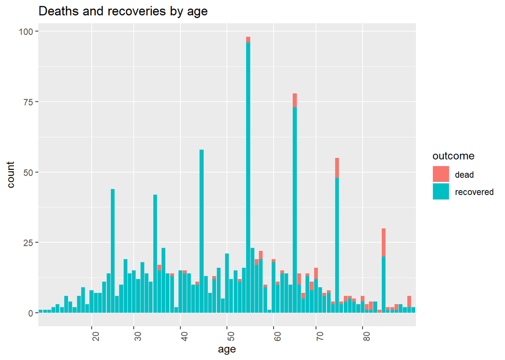

Two features stick out in the above graph: The first, while we hear that the elderly are much more likely to contract COVID-19 and face harsher symptoms of the disease, the data above does not seem to reflect that individuals over the age of 70 are more likely to contract. This could be due to a couple of different reasons: a potentially lower population of those over the age of 70 or the fact that multiple countries healthcare systems were overwhelmed by the number of cases meaning healthcare professionals were forced to triage the hospitalized by likeliness of survival. The second, is the large spikes in the centers of the 20s, 30s, 40s, etc. We expect this is due to an approximation of individuals with unknown ages.

```
## # A tibble: 20 x 3
##    summary                                                        age   outcome
##    <chr>                                                          <chr> <chr>
##  1 new confirmed imported COVID-19 pneumonia patient in Henan: m… 55    recover…
##  2 new confirmed imported COVID-19 pneumonia patient in Beijing:… 45    recover…
##  3 Death from COVID-19 pneumonia in Wuhan: male, 75, symptom ons… 75    dead
##  4 Death from COVID-19 pneumonia in Wuhan: male, 65, symptom ons… 65    dead
##  5 new confirmed imported COVID-19 pneumonia patient in Hunan: m… 45    recover…
##  6 new death from COVID-19 pneumonia, female, 85, death on 01/21… 85    dead
##  7 new death from COVID-19 pneumonia, female, 65, hospitalized o… 65    dead
##  8 Death from COVID-19 pneumonia in Wuhan: male, 55, symptom ons… 55    dead
##  9 Death from COVID-19 pneumonia in Wuhan: male, 65, symptom ons… 65    dead
## 10 new confirmed imported COVID-19 pneumonia patient 01/25-No.5 … 45    recover…
## 11 new confirmed imported COVID-19 pneumonia patient 01/25-No.10… 15    recover…
## 12 confirmed COVID-19 pneumonia patient No.11 in Tianjin: female… 55    recover…
## 13 <NA>                                                           35    recover…
## 14 new confirmed COVID-19 pneumonia patient in Yunnan: female, 5… 55    recover…
## 15 new confirmed COVID-19 pneumonia patient in Yunnan: male, 65,… 65    recover…
## 16 new confirmed COVID-19 patient in France: male, 55, hospitali… 55    recover…
## 17 new confirmed COVID-19 patient in France: Annecy, 60s, friend… 65    recover…
## 18 new confirmed COVID-19 patient in France: Annecy, 30s, female… 35    recover…
## 19 new confirmed COVID-19 patient in France: Pays de la Loire, f… 25    recover…
## 20 new confirmed COVID-19 patient in France: Pays de la Loire, m… 25    recover…
```

```
## # A tibble: 20 x 3
##    summary                                                        age   outcome
##    <chr>                                                          <chr> <chr>
##  1 new confirmed COVID-19 patient in France: Annecy, 60s, friend… 65    recover…
##  2 new confirmed COVID-19 patient in France: Annecy, 30s, female… 35    recover…
##  3 new confirmed COVID-19 patient in Japan:  male, in his 30s, K… 35    recover…
##  4 new confirmed COVID-19 patient in Japan: male, in his 40s, Wu… 45    recover…
##  5 new confirmed COVID-19 patient in Japan: female, in her 30s, … 35    recover…
##  6 new confirmed COVID-19 patient in Japan: male, in his 40s, Wu… 45    recover…
##  7 new confirmed COVID-19 patient in Japan: male, in his 40s, Wu… 45    recover…
##  8 new confirmed COVID-19 patient in Japan: 1/28-No.1, male, in … 65    recover…
##  9 new confirmed COVID-19 patient in Japan: female, in her 40s, … 45    recover…
## 10 new confirmed COVID-19 patient in Japan: female, in her 40s, … 45    recover…
## 11 new confirmed COVID-19 patient in Japan: male, in his 50s, ar… 55    recover…
## 12 new confirmed COVID-19 patient in Japan: male, in his 50s, fo… 55    recover…
## 13 new confirmed COVID-19 patient in Japan: female, in her 30s, … 35    recover…
## 14 new confirmed COVID-19 patient in Japan: female, in her 20s, … 25    recover…
## 15 new confirmed COVID-19 patient in Japan: female, in her 20s, … 25    recover…
## 16 new confirmed COVID-19 patient in Japan: male, in his 40s, ev… 45    recover…
## 17 new confirmed COVID-19 patient in Japan: male, in his 40s, sy… 45    recover…
## 18 new confirmed COVID-19 patient in Japan: male, 30s, returned … 35    recover…
## 19 new confirmed COVID-19 patient in Japan: female, 30s, lives i… 35    recover…
## 20 new confirmed COVID-19 patient in Japan: female, 50s, lives i… 55    recover…
```

```
## [1] 0.7865707
```

To see if this assumption is true, I took a deeper look into the uncleaned dataset, particularly at the summary column and age column. Looking through the first dataframe above (a dataframe with only ages that end five): the summary contains a description of ages that end in five, but also estimates of ages such as “60s” or “30s”. The second dataframe searches the summary to isolate the descriptions that contain these estimates of ages. Dividing the number of entries in the second dataframe from the number of entries in the first produces the third output: a ratio of approximately 0.79. Meaning, that these large spikes in the centers of 20s, 30s, 40s, etc. are caused by an approximation of individuals by the healthcare workers who produced the dataset.

## Exploration of how fast is COVID-19 spreading globally

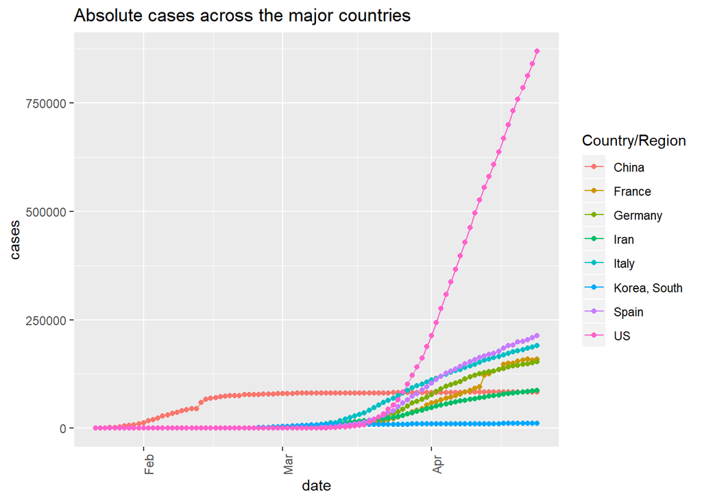

# Results

## How fast is the virus spreading by Country?

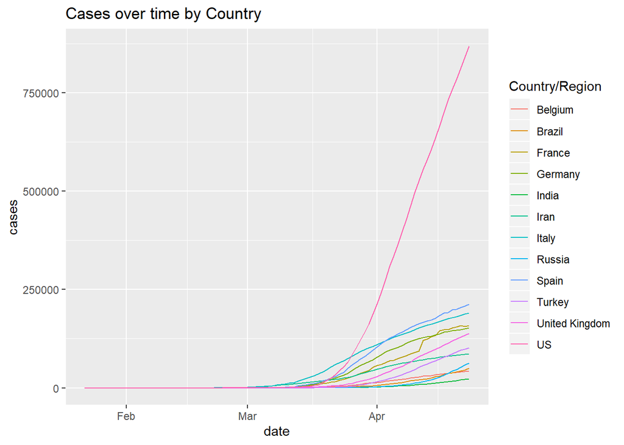

```r
df <- filter(data, `Country/Region` == "US" | `Country/Region` == "Spain" | `Country/Region` == "Italy" | `Country/Region` == "France" | `Country/Region` == "Germany" | `Country/Region` == "Iran" | `Country/Region` == "United Kingdom" | `Country/Region` == "Turkey" | `Country/Region` == "Belgium" | `Country/Region` == "Russia" | `Country/Region` == "Brazil" | `Country/Region` == "Canada"  | `Country/Region` == "India")
df <- filter(df, is.na(`Province/State`))
ggplot(df, aes(x=date, y=cases, color=`Country/Region`)) +
  geom_line() + ggtitle("Cases over time by Country")
```

As we can see, the US has the highest number of cases to date, as well as one of the steepest curves. While most nearly all other countries shown in the graph began seeing their first cases the beginning of March, the US had their first case approximately two weeks later. The graph below shows the cases in several countries after the US’ first major spike in cases.

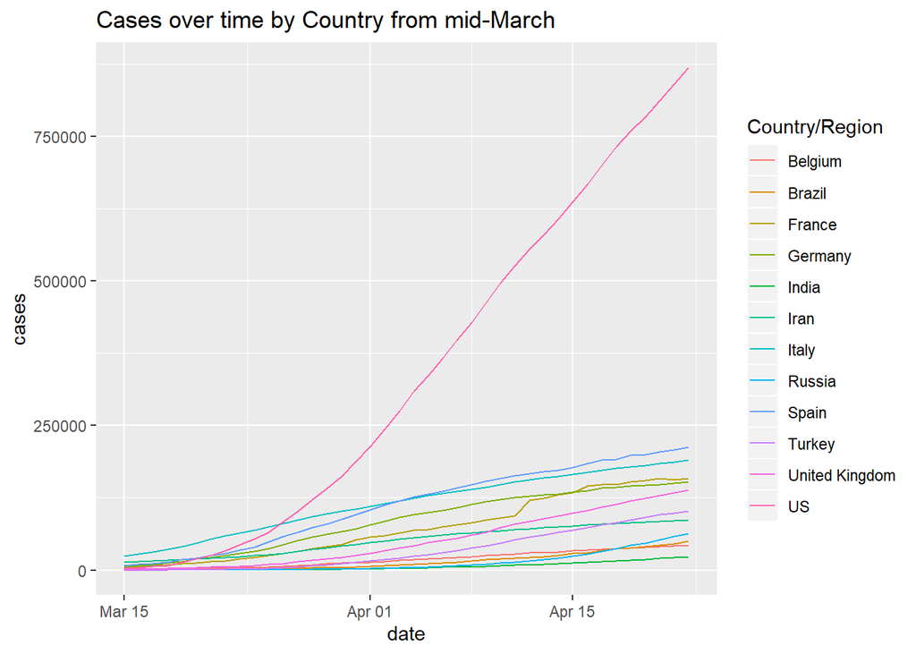

```r
df <- filter(df, date >= "2020-3-15")
ggplot(df, aes(x=date, y=cases, color=`Country/Region`)) +
  geom_line() + ggtitle("Cases over time by Country from mid-March")
```

## How do different groups fare after testing positive for COVID-19?

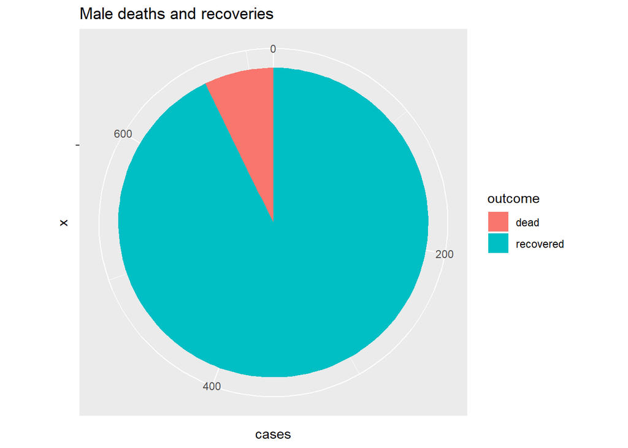

```r
gender <- filter(patient_data, !is.na(gender)) %>%
  select(gender, outcome)
male <- gender[gender$gender == "male",] %>% group_by(outcome) %>%
  summarise(cases = n())
female <- gender[gender$gender == "female",] %>% group_by(outcome) %>%
  summarise(cases = n())
mpie <- ggplot(male, aes(x="",y=cases,fill=outcome)) + geom_bar(stat ="identity", width=1) + ggtitle("Male deaths and recoveries") + coord_polar("y", start=0)
fpie <- ggplot(female, aes(x="",y=cases,fill=outcome)) + geom_bar(stat ="identity", width=1) + ggtitle("Female deaths and recoveries") + coord_polar("y", start=0)
mpie
```

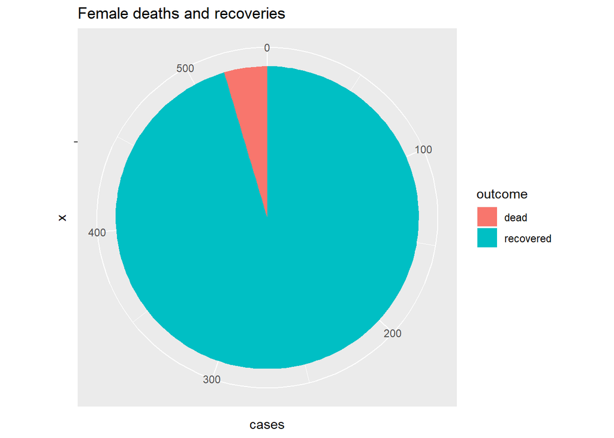

```r
fpie
```

From the above graphics, we can see that presumably more men than women show symptoms after contracting COVID-19 as the number of male cases is larger than the number of female cases. Which, seems to be supported by studies of hospitalized individuals in the US [The New Coronavirus Appears to Take a Greater Toll on Men Than On Women.](https://www.npr.org/sections/goatsandsoda/2020/04/10/831883664/the-new-coronavirus-appears-to-take-a-greater-toll-on-men-than-on-women) Also noticeable in the above graphics, is the larger proportion of deaths in males resulting from COVID-19 than in females.

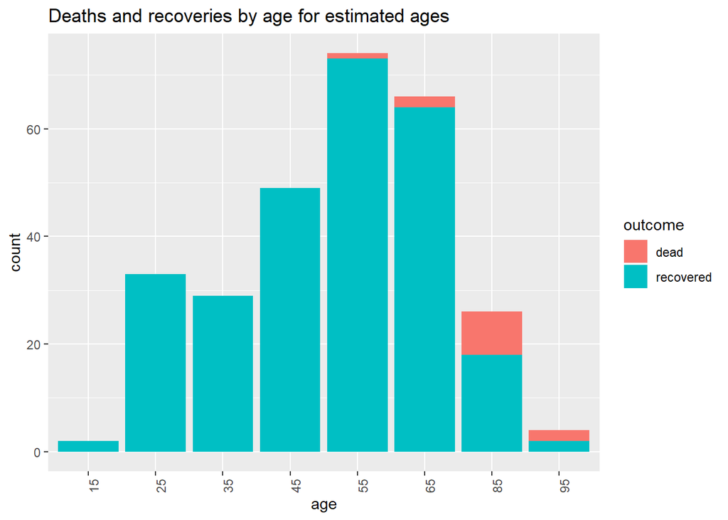

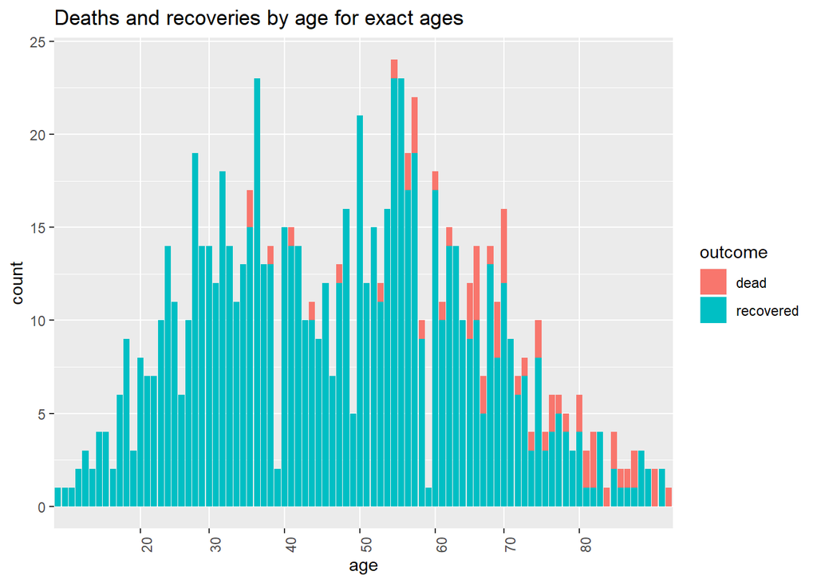

Given my realization about the outliers in the data description portion of this project, I thought it would be best, for visualization purposes, to isolate the observations that contained estimated patient’s ages and observations that contained the patient’s exact ages. This produced the two graphs above. In both visualizations, we can see that, while symptomatic cases peak in the mid-50s and begin to taper off from 60 and above, there are far more cases of COVID-19 that result in death in these more elderly victims.

## When will the spread plateau?

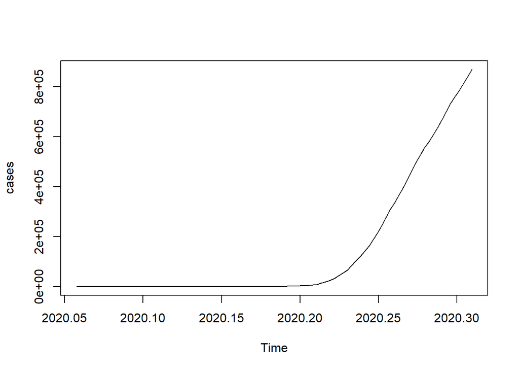

```r
modelData <- filter(select(data, -'Province/State'), `Country/Region`=="US")
modelData <- select(modelData, -`Country/Region`,-Lat, -Long,-date)
set.seed(25)
myts <- ts(modelData,
           start = c(2020, 22), end = c(2020, 114),
           frequency = 365)
plot(myts)
```

```r
arima_model <- auto.arima(myts)
summary(arima_model)
```

```
## Series: myts
## ARIMA(0,2,0)
##
## sigma^2 estimated as 2906261:  log likelihood=-806.27
## AIC=1614.54   AICc=1614.59   BIC=1617.05
##
## Training set error measures:
##                    ME     RMSE      MAE     MPE     MAPE MASE       ACF1
## Training set 309.8817 1686.346 837.7957 1.85698 8.686816  NaN 0.02590303
```

```r
fore_arima = forecast::forecast(arima_model, h=92)
fore_arima
```

```
##           Point Forecast     Lo 80     Hi 80     Lo 95     Hi 95
## 2020.3123         897989  895804.2  900173.8  894647.7  901330.3
## 2020.3151         926808  921922.7  931693.3  919336.6  934279.4
## 2020.3178         955627  947452.4  963801.6  943125.0  968129.0
## 2020.3205         984446  972479.6  996412.4  966144.9 1002747.1
## 2020.3233        1013265  997062.4 1029467.6  988485.3 1038044.7
## 2020.3260        1042084 1021242.7 1062925.3 1010210.0 1073958.0
## 2020.3288        1070903 1045052.6 1096753.4 1031368.2 1110437.8
## 2020.3315        1099722 1068517.4 1130926.6 1051998.7 1147445.3
## 2020.3342        1128541 1091658.0 1165424.0 1072133.4 1184948.6
## 2020.3370        1157360 1114491.9 1200228.1 1091799.0 1222921.0
## 2020.3397        1186179 1137034.1 1235323.9 1111018.3 1261339.7
## 2020.3425        1214998 1159297.4 1270698.6 1129811.2 1300184.8
## 2020.3452        1243817 1181293.2 1306340.8 1148195.1 1339438.9
## 2020.3479        1272636 1203031.6 1342240.4 1166185.3 1379086.7
## 2020.3507        1301455 1224521.7 1378388.3 1183795.7 1419114.3
## 2020.3534        1330274 1245771.6 1414776.4 1201038.7 1459509.3
## 2020.3562        1359093 1266788.6 1451397.4 1217925.6 1500260.4
## 2020.3589        1387912 1287579.5 1488244.5 1234466.7 1541357.3
## 2020.3616        1416731 1308150.5 1525311.5 1250671.4 1582790.6
## 2020.3644        1445550 1328507.3 1562592.7 1266548.6 1624551.4
## 2020.3671        1474369 1348655.2 1600082.8 1282106.3 1666631.7
## 2020.3699        1503188 1368599.1 1637776.9 1297352.0 1709024.0
## 2020.3726        1532007 1388343.6 1675670.4 1312292.7 1751721.3
## 2020.3753        1560826 1407892.9 1713759.1 1326935.0 1794717.0
## 2020.3781        1589645 1427251.2 1752038.8 1341285.0 1838005.0
## 2020.3808        1618464 1446422.1 1790505.9 1355348.6 1881579.4
## 2020.3836        1647283 1465409.2 1829156.8 1369131.1 1925434.9
## 2020.3863        1676102 1484216.0 1867988.0 1382637.7 1969566.3
## 2020.3890        1704921 1502845.6 1906996.4 1395873.4 2013968.6
## 2020.3918        1733740 1521301.0 1946179.0 1408842.6 2058637.4
## 2020.3945        1762559 1539585.2 1985532.8 1421549.9 2103568.1
## 2020.3973        1791378 1557700.7 2025055.3 1433999.5 2148756.5
## 2020.4000        1820197 1575650.4 2064743.6 1446195.3 2194198.7
## 2020.4027        1849016 1593436.6 2104595.4 1458141.1 2239890.9
## 2020.4055        1877835 1611061.8 2144608.2 1469840.6 2285829.4
## 2020.4082        1906654 1628528.2 2184779.8 1481297.2 2332010.8
## 2020.4110        1935473 1645838.0 2225108.0 1492514.4 2378431.6
## 2020.4137        1964292 1662993.3 2265590.7 1503495.4 2425088.6
## 2020.4164        1993111 1679996.2 2306225.8 1514243.2 2471978.8
```

[output cut: 38 more lines]

```
## 2020.5233        3117052 2239771.5 3994332.5 1775367.3 4458736.7
## 2020.5260        3145871 2251773.5 4039968.5 1778466.8 4513275.2
## 2020.5288        3174690 2263669.3 4085710.7 1781404.1 4567975.9
## 2020.5315        3203509 2275459.7 4131558.3 1784180.1 4622837.9
## 2020.5342        3232328 2287145.3 4177510.7 1786795.9 4677860.1
## 2020.5370        3261147 2298726.8 4223567.2 1789252.3 4733041.7
## 2020.5397        3289966 2310204.8 4269727.2 1791550.5 4788381.5
## 2020.5425        3318785 2321579.8 4315990.2 1793691.2 4843878.8
## 2020.5452        3347604 2332852.5 4362355.5 1795675.5 4899532.5
## 2020.5479        3376423 2344023.5 4408822.5 1797504.2 4955341.8
## 2020.5507        3405242 2355093.4 4455390.6 1799178.3 5011305.7
## 2020.5534        3434061 2366062.7 4502059.3 1800698.5 5067423.5
## 2020.5562        3462880 2376932.0 4548828.0 1802065.8 5123694.2
## 2020.5589        3491699 2387701.8 4595696.2 1803281.1 5180116.9
## 2020.5616        3520518 2398372.8 4642663.2 1804345.0 5236691.0
```

As per Professor Brown’s suggestion, we decided to use a time series regression model to forecast the number of cases in the US. We wanted to find out when/if the spread would plateau, and in order to answer the question, we decided to forecast the next 92 days of the cases in the US, using the ARIMA modeling method. Unfortunately, what we see is an increase in cases rather than any decrease whatsoever, based on current trends. Our model forecasts that in 92 days, there will be over 3.5 million infected.

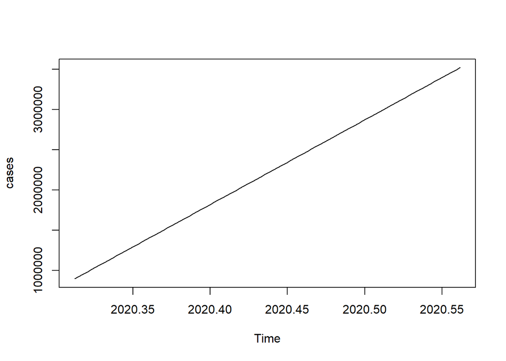

```r
modelData2 <- as.data.frame(fore_arima$mean) %>% rename(cases=x)
ts(modelData2, start = c(2020, 115), end = c(2020, 206),
           frequency = 365) %>% plot()
```

In order to confirm our findings, we decided to search the internet. We found [this](https://www.weforum.org/agenda/2020/04/how-and-when-will-this-pandemic-end-we-asked-a-virologist/) article, written on April 06, which describes how the number of cases may increase until a point of saturation is reached. This article is consistent with our findings since the ‘point of saturation’ described in the article is somewhere between 40-50% of the population. Other sources, however, such as [this one by the New York Times](https://www.nytimes.com/interactive/2020/04/22/upshot/coronavirus-models.html), forecast a decrease in the number of deaths (and therefore cases) of the coronavirus within the next 30 days.

## How effective is the quarantine, if at all?

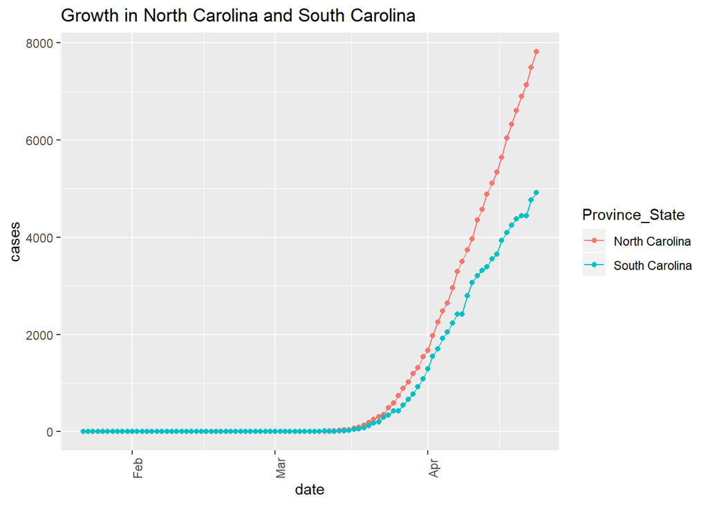

North Carolina enacted a stay at home policy a week before South Carolina (March 30th vs April 7th), and because of their proximity and similarity, it seemed like a good case to dive into. However, from what it looks like here, there really isn’t a significant difference between the overall numbers or the perceived growth in the two regions. In fact, if we’re really nitpicking, it appears that North Carolina has maintained a linear growth percentage while South Carolina has somewhat tailed off in the recent weeks. In order to see if quarantine has had a noticeable benefit, we’ll have to push further.

The first thing we’ll look at is the difference between what rank (1-51, including DC) they number of cases was on the day each state ordered their stay-at-home order and the last day we have data, 4/23, and compare that to the day they ordered it. For cleanliness, states that did not order a statewide stay-at-home order have been removed. A simplified dataset that has been created manually in order to pull in the stay-at-home dates has been added.

For reference, the more positive a rank, the more the cases decreased in that state relative to other states.

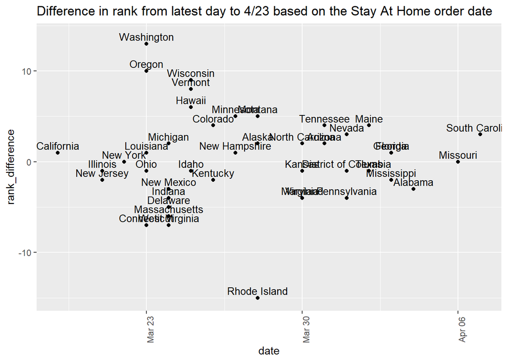

Interestingly, there doesn’t appear to be an overarching trend relating the date of the stay-at-home order effects when compared to how the national ranking of each state’s cases changed. Let’s look when comparing their normalized ranks. Again, a positive rank_difference indicates that this state’s cases decreased relative to other states.

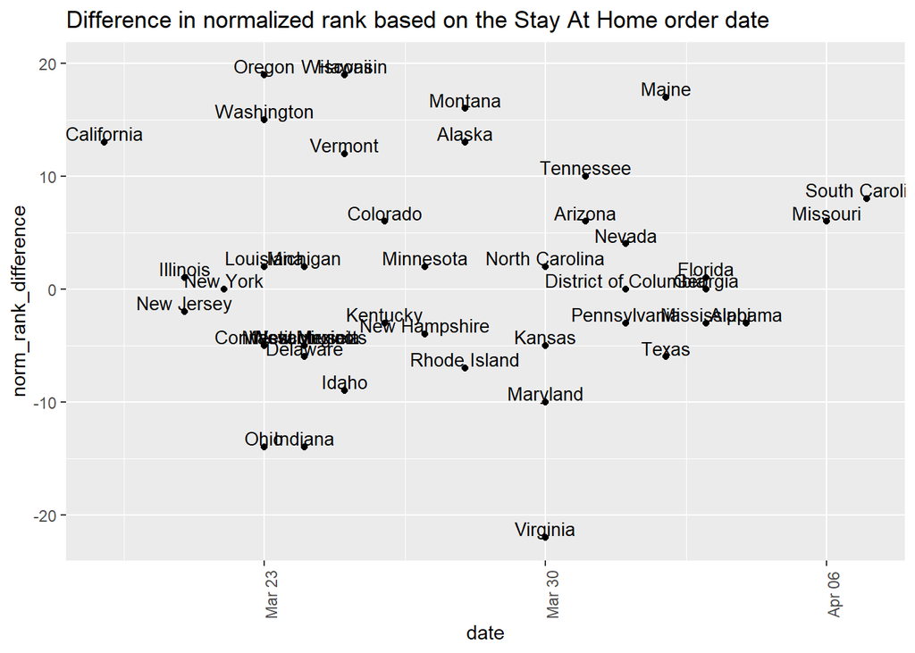

There are more states above 0 than below 0, which indicates that states are more likely to go down in the rankings (have fewer cases relative to others) after they quarantine, which makes sense. However, it’s not entirely conclusive, which can likely be drawn up to the fact A) that so many states quarantined at about the same time and B) there are a lot of factors outside of just the quarantine date like simply the rate and stage of growth of surrounding states (the later a Northeastern state quarantined, the lower it is on the graph) as well as the unpredictability of who gets tested.

If we instead wanted to look at the rate of growth of each state before and after quarantining, one way would be to isolate the dates around each quarantine date. If we look at the preceding 2 weeks and the succeedings two weeks of a select few states, the data appears as so:

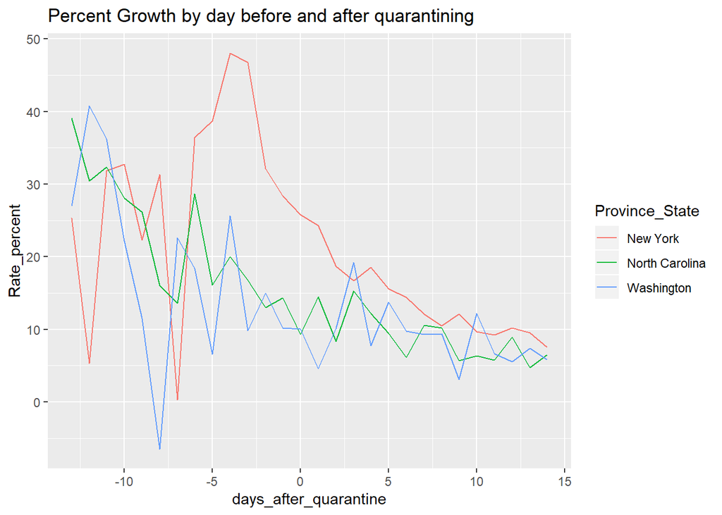

## How fast is COVID-19 spreading globally?

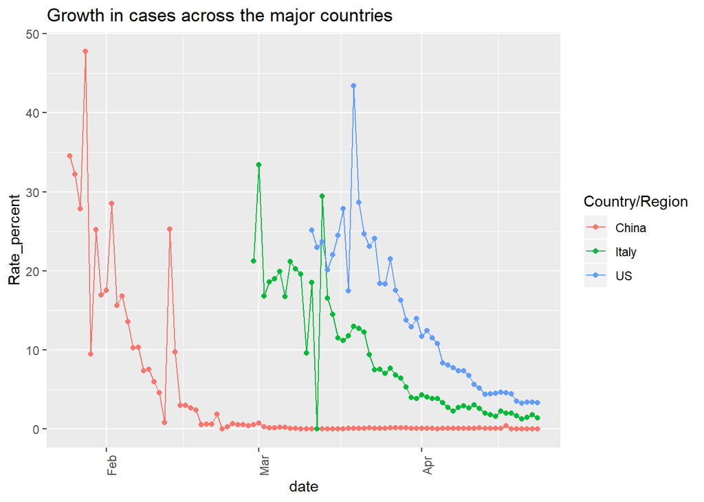